# Estimating tips

Alex Faidiga

April 8, 2020

### Finding the best estimate of discrete tip state for missing data at a single tip:

```r
library(ape)
library(phytools)
library(geiger)
```

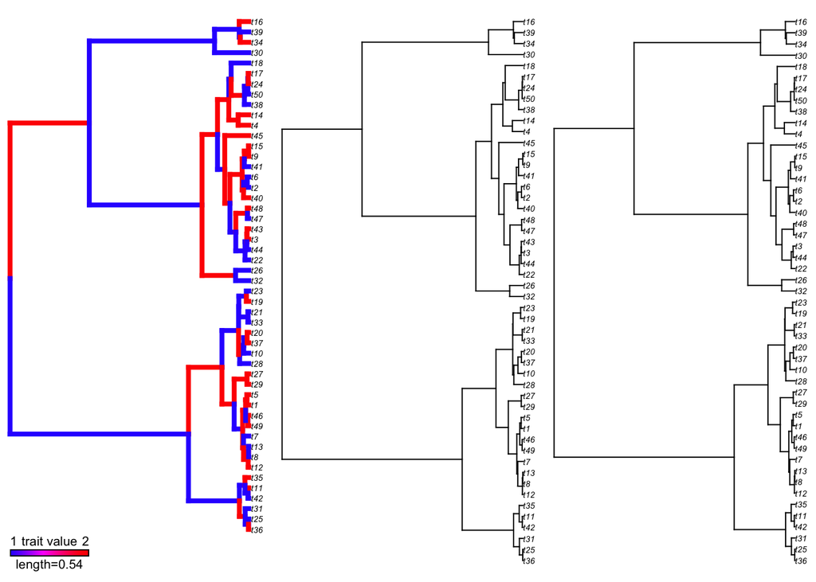

```r
library(data.table)

#rate matrix structure
#rates of transition from 1->2 and 2->1 are different
#    1  2
# 1 -a  a
# 2  b -b

#set rates for simulated data
r12 <- 15
r21 <- 15
ntax <- 50

#create phylogeny
phy <- ape::rcoal(ntax)

#create rate matrix
q <- list(rbind(c(-r12, r12), c(r21, -r21)))

#simulate discrete traits using rate matrix
traits <- geiger::sim.char(phy=phy, par=q, nsim=1, model="discrete", root=1)[,,1]

#delete random taxon to simulate missing data
taxon_to_delete <- sample(sequence(ntax), 1)

#delete trait and create phylogeny for deleted taxon
traits_changed <- traits[-taxon_to_delete]
phy_changed <- ape::drop.tip(phy, names(traits)[taxon_to_delete])

#visualize trees
par(mfcol=c(1,3))
plotBranchbyTrait(phy, traits, mode=c("edges"), palette="rainbow")
plot(phy)
plot(phy_changed)
```

```r
#get MLEs of transition rates and likelihood from tree
model_fit <- geiger::fitDiscrete(phy=phy_changed, dat=traits_changed, model="ARD", transform="none")
model_fit
```

```
## GEIGER-fitted comparative model of discrete data
##  fitted Q matrix:
##               1         2
##     1 -28.52259  28.52259
##     2  24.77248 -24.77248
##
##  model summary:
##  log-likelihood = -30.752202
##  AIC = 65.504404
##  AICc = 65.765273
##  free parameters = 2
##
## Convergence diagnostics:
##  optimization iterations = 100
##  failed iterations = 0
##  frequency of best fit = 0.43
##
##  object summary:
##  'lik' -- likelihood function
##  'bnd' -- bounds for likelihood search
##  'res' -- optimization iteration summary
##  'opt' -- maximum likelihood parameter estimates
```

```r
q12 <- model_fit$opt[[1]]
q21 <- model_fit$opt[[2]]

#assign character state = 1 to the missing taxon and calculate likelihood
traits_1 <- traits
traits_1[taxon_to_delete] <- 1
model_fit_1 <- geiger::fitDiscrete(phy=phy, dat=traits_1, model="ARD", transform="none")
model_fit_1$opt
```

```
## $q12
## [1] 37.98119
##
## $q21
## [1] 34.64807
##
## $lnL
## [1] -31.89958
##
## $method
## [1] "L-BFGS-B"
##
## $k
## [1] 2
##
## $aic
## [1] 67.79916
##
## $aicc
## [1] 68.05448
```

```r
#assign character state = 2 to the missing taxon and calculate likelihood
traits_2 <- traits
traits_2[taxon_to_delete] <- 2
model_fit_2 <- geiger::fitDiscrete(phy=phy, dat=traits_2, model="ARD", transform="none")

#extract likelihood and AICc values
likelihood_values <- c(model_fit_1[[4]]$lnL, model_fit_2[[4]]$lnL)
names(likelihood_values) <- c("model 1", "model 2")

AICc_values <- c(model_fit_1[[4]]$aicc, model_fit_2[[4]]$aicc)
AICc_values <- c(model_fit_1[[4]]$aicc-min(AICc_values), model_fit_2[[4]]$aicc-min(AICc_values))
names(AICc_values) <- c("model 1", "model 2")

results <- matrix(c(likelihood_values, AICc_values), byrow = FALSE, nrow = 2, dimnames = list(c("Model 1","Model 2"), c("log-likelihood","AICc")))

#print "true" trait data, trait data for models, and results for models
print(taxon_to_delete)
```

```
## [1] 30
```

```r
print(rbind(traits, traits_1, traits_2))
```

```
##          t36 t25 t31 t42 t11 t35 t12 t8 t13 t7 t49 t46 t1 t5 t29 t27 t28 t10
## traits     1   1   2   1   2   1   1  1   1  1   2   2  2  2   1   2   2   2
## traits_1   1   1   2   1   2   1   1  1   1  1   2   2  2  2   1   2   2   2
## traits_2   1   1   2   1   2   1   1  1   1  1   2   2  2  2   1   2   2   2
##          t37 t20 t33 t21 t19 t23 t32 t26 t22 t44 t3 t43 t47 t48 t40 t2 t6 t41
## traits     2   1   1   1   2   1   2   2   2   2  2   2   2   2   1  2  1   1
## traits_1   2   1   1   1   2   1   2   2   2   2  2   1   2   2   1  2  1   1
## traits_2   2   1   1   1   2   1   2   2   2   2  2   2   2   2   1  2  1   1
##          t9 t15 t45 t4 t14 t38 t50 t24 t17 t18 t30 t34 t39 t16
## traits    1   1   2  2   1   1   1   1   1   2   1   2   1   2
## traits_1  1   1   2  2   1   1   1   1   1   2   1   2   1   2
## traits_2  1   1   2  2   1   1   1   1   1   2   1   2   1   2
```

```r
print(results)
```

```
##         log-likelihood     AICc
## Model 1      -31.89958 1.687568
## Model 2      -31.05580 0.000000
```

### Estimating the most likely tip states for a tree with missing data for multiple taxa:

```r
#set rates for simulated data
r12 <- 15
r21 <- 10
ntax <- 15

#create phylogeny
phy <- ape::rcoal(ntax)

#create rate matrix
q <- list(rbind(c(-r12, r12), c(r21, -r21)))

#simulate discrete traits using rate matrix
traits <- geiger::sim.char(phy=phy, par=q, nsim=1, model="discrete", root=1)[,,1]

#delete random taxa to simulate missing data
taxa_to_delete <- sample(sequence(ntax), 3, replace = FALSE)

#delete trait and create phylogeny for deleted taxon
traits_changed <- traits[-taxa_to_delete]
phy_changed <- ape::drop.tip(phy, names(traits)[taxa_to_delete])

#get MLEs of transition rates and likelihood from tree for which missing tips are dropped
model_fit <- geiger::fitDiscrete(phy=phy_changed, dat=traits_changed, model="ARD", transform="none")
model_fit
```

```
## GEIGER-fitted comparative model of discrete data
##  fitted Q matrix:
##               1         2
##     1 -377.5104  377.5104
##     2  125.8368 -125.8368
##
##  model summary:
##  log-likelihood = -6.748022
##  AIC = 17.496044
##  AICc = 18.829377
##  free parameters = 2
##
## Convergence diagnostics:
##  optimization iterations = 100
##  failed iterations = 0
##  frequency of best fit = 0.19
##
##  object summary:
##  'lik' -- likelihood function
##  'bnd' -- bounds for likelihood search
##  'res' -- optimization iteration summary
##  'opt' -- maximum likelihood parameter estimates
```

```r
q12 <- model_fit$opt[1]
q21 <- model_fit$opt[2]
```

#### BestTips function: This function will calculate the likelihood and AICc for every possible combination of traits for missing tips and return a list containing model results and a vector of the trait values with the highest likelihood. Must provide a tree, vector of trait data and vector of indexes for tips that have missing data.

```r
BestTips <- function(phy, trait.data, replaced.traits.index){
  replaced.traits <- trait.data
  sim.traits <- do.call(CJ, replicate(length(replaced.traits.index), 1:2, FALSE))
  trait.possibilities <- data.frame(matrix(nrow=nrow(sim.traits), ncol=(length(replaced.traits))))

  for(i in 1:nrow(sim.traits)){
    replaced.traits[replaced.traits.index] <- sim.traits[i]
    trait.possibilities[i,] <- replaced.traits
    colnames(trait.possibilities) <- names(trait.data)
}
  traits <- as.matrix(trait.possibilities)
  df <- data.frame(matrix(nrow=nrow(traits), ncol = 3))
  colnames(df) <- c("Trait combination","Log-likelihood", "AICc")

  for(i in 1:nrow(traits)){
      model.results <- geiger::fitDiscrete(phy=phy, dat=traits[i,], model="ARD", transform="none")
    df[i,] <- c(i, model.results[[4]]$lnL, model.results[[4]]$aicc)
  }
  df$AICc <- df$AICc-min(df$AICc)
  best.traits <- traits[df[df$AICc == 0,]$`Trait combination`,]
  results <- list(df, best.traits)
  return(results)
}

final.results <- BestTips(phy = phy, trait.data = traits, replaced.traits.index = taxa_to_delete)
final.results
```

```
## [[1]]
##   Trait combination Log-likelihood     AICc
## 1                 1     -10.095176 5.202018
## 2                 2      -9.547716 4.107099
## 3                 3      -9.547716 4.107099
## 4                 4      -8.698740 2.409146
## 5                 5      -9.500461 4.012589
## 6                 6      -8.673337 2.358339
## 7                 7      -8.673187 2.358040
## 8                 8      -7.494167 0.000000
##
## [[2]]
##  t9  t5 t11  t2  t1 t15  t3 t14 t10  t4  t7 t12  t8  t6 t13
##   2   2   2   2   2   1   1   2   2   2   2   1   2   2   2
```

### Next steps in the future: try with real data and see how accurately it estimates tips, make figure displaying phylogeny with data estimated from BestTips, confidence intervals, figures showing limitations of the function (e.g. how well it works for trees of different sizes and numbers of missing tips).

### Also, I want to find a way to provide the rate matrix estimated from the phylogeny with missing data rather than fitDiscrete calculating them separately for every set of traits.